# Ch 3: Sampling the Imaginary

What’s the probability of someone being a vampire?

```r
PrPV <- 0.95
PrPM <- 0.01
PrV <- 0.001

PrP <- PrPV * PrV + PrPM * (1 - PrV)
PrVP <- PrPV * PrV / PrP
PrVP
```

```
[1] 0.08683729
```

## Sampling from a grid-approximate posterior

Generate 1,000 values for the posterior distribution (back to the globe example from Ch 2)

```r
p_grid <- seq(0, 1, length.out = 1e3)
prior <- rep(1, length(p_grid))
likelihood <- dbinom(6, size = 9, prob = p_grid)
posterior <- (likelihood * prior) %>% {. / sum(.)}
```

Draw 10,000 samples from the posterior

```r
samples <- sample(p_grid, prob = posterior, size = 1e4, replace= TRUE)
```

Plot the samples and their density

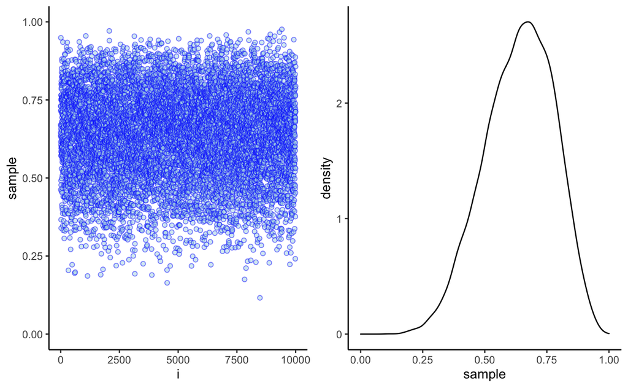

```r
sample_tbl <- tibble(i = seq_along(samples), sample = samples)
plot_grid(
  ggplot(sample_tbl, aes(i, sample)) +
    geom_point(color = "blue", fill = "light blue", alpha = 0.5, shape = 21) +
    expand_limits(y = c(0, 1)) +
    theme_classic(),
  ggplot(sample_tbl, aes(sample)) +
    geom_density() +
    expand_limits(x = c(0, 1)) +
    theme_classic()
)
```

## Sampling to summarize

### Intervals of defined boundaries

Posterior probability the proportion of water is less than 0.5?

```r
# add up the posterior probability where p < 0.5
sum(posterior[p_grid < 0.5])
```

```
[1] 0.1718746
```

Now with the samples

```r
# below 0.5?
sum(samples < 0.5) / length(samples)
```

```
[1] 0.1682
```

```r
# between 0.5 and 0.75?
sum(samples > 0.5 & samples < 0.75) / length(samples)
```

```
[1] 0.6002
```

### Intervals of defined mass

Where’s the 80th percentile?

```r
quantile(samples, 0.8)
```

```
      80%
0.7627628
```

What’s the middle 80%?

```r
quantile(samples, c(0.1, 0.9))
```

```
      10%       90%
0.4504505 0.8128128
```

How about with a skewed distribution? The 50% **percentile interval** no longer contains the mode of the distribution and is therefore misleading.

```r
p_grid <- seq(0, 1, length.out = 1e3)
prior <- rep(1, length(p_grid))
likelihood <- dbinom(3, size = 3, prob = p_grid)
posterior <- (likelihood * prior) %>% {. / sum(.)}
samples <- sample(p_grid, size = 1e4, replace = TRUE, prob = posterior)
PI(samples, prob = 0.5)
```

```
      25%       75%
0.7077077 0.9299299
```

Conversely, the **highest posterior density interval** is the narrowest interval containing the specified probability mass.

```r
HPDI(samples, prob = 0.5)
```

```
     |0.5      0.5|
0.8398398 1.0000000
```

### Point estimates

**The entire posterior distribution is the Bayesian parameter estimate**, but if you have to report one number what should you choose?

Mode, mean, median?

```r
# maximum a posteriori estimate
p_grid[which.max(posterior)]
```

```
[1] 1
```

```r
# mode of the samples
dsamples <- density(samples, adj = 0.01)
dsamples$x[which.max(dsamples$y)]
```

```
[1] 0.9971726
```

```r
# other central tendencies
mean(samples)
```

```
[1] 0.8007832
```

```r
median(samples)
```

```
[1] 0.8398398
```

## Sampling to simulate prediction

Generate samples from a binomial and check their densities.

```r
dummy_w <- rbinom(1e5, size = 2, prob = 0.7)
table(dummy_w) / length(dummy_w)
```

```
dummy_w
      0       1       2
0.08910 0.42067 0.49023
```

```r
dbinom(0:2, size = 2, prob = 0.7)
```

```
[1] 0.09 0.42 0.49
```

**Posterior predictive distribution** - what does a parameter predict? It’s not the same as the posterior distribution itself, because each $p$ generates a different distribution of predictions. But we can average those prediction distributions of the posterior distribution.

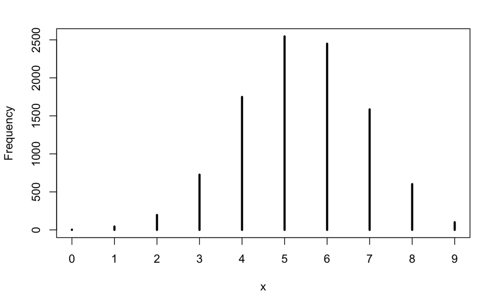

```r
# This is the prediction distribution for a given p
w <- rbinom(1e4, size = 9, prob = 0.6)
simplehist(w)
```

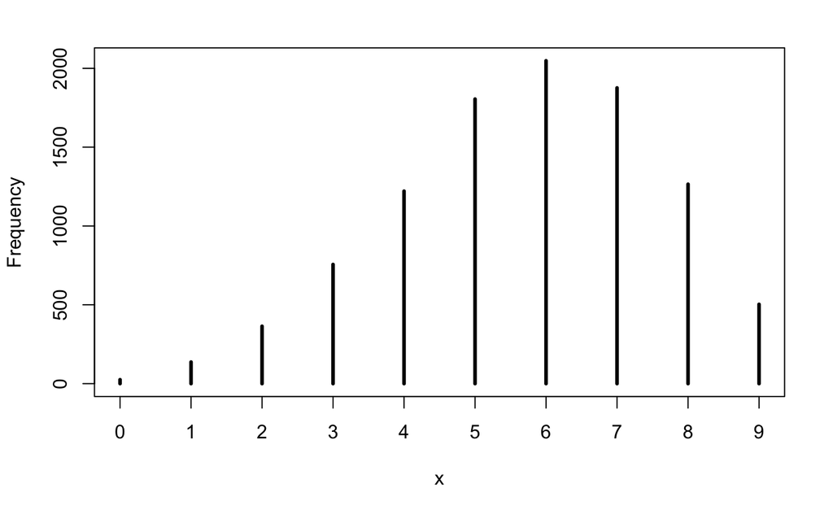

```r
# This is the prediction distribution averaged over all p's
p_grid <- seq(0, 1, length.out = 1e3)
prior <- rep(1, length(p_grid))
likelihood <- dbinom(6, size = 9, prob = p_grid)
posterior <- (likelihood * prior) %>% {. / sum(.)}
samples <- sample(p_grid, prob = posterior, size = 1e4, replace = TRUE)
w <- rbinom(1e4, size = 9, prob = samples)
simplehist(w)
```

## Exercises

### Easy

```r
p_grid <- seq(0, 1, length.out = 1e3)
prior <- rep(1, length(p_grid))
likelihood <- dbinom(6, size = 9, prob = p_grid)
posterior <- (likelihood * prior) %>% {. / sum(.)}
set.seed(100)
samples <- sample(p_grid, prob = posterior, size = 1e4, replace = TRUE)
```

3e1

```r
sum(samples < 0.2) / length(samples)
```

```
[1] 4e-04
```

3e2

```r
sum(samples > 0.8) / length(samples)
```

```
[1] 0.1116
```

3e3

```r
sum(samples > 0.2 & samples < 0.8) / length(samples)
```

```
[1] 0.888
```

3e4

```r
quantile(samples, 0.2)
```

```
      20%
0.5185185
```

3e5

```r
quantile(samples, 0.8)
```

```
      80%
0.7557558
```

3e6

```r
HPDI(samples, prob = 0.66)
```

```
    |0.66     0.66|
0.5085085 0.7737738
```

3e7

```r
quantile(samples, c((1 - 0.66) / 2, 1 - (1 - 0.66) / 2))
```

```
      17%       83%
0.5025025 0.7697698
```

### Medium

3m1

```r
p_grid <- seq(0, 1, length.out = 1e3)
prior <- rep(1, length(p_grid))
likelihood <- dbinom(8, size = 15, prob = p_grid)
posterior <- (likelihood * prior) %>% {. / sum(.)}
```

3m2

```r
samples <- sample(p_grid, 1e4, prob = posterior, replace = TRUE)
HPDI(samples, prob = 0.9)
```

```
     |0.9      0.9|
0.3293293 0.7167167
```

3m3

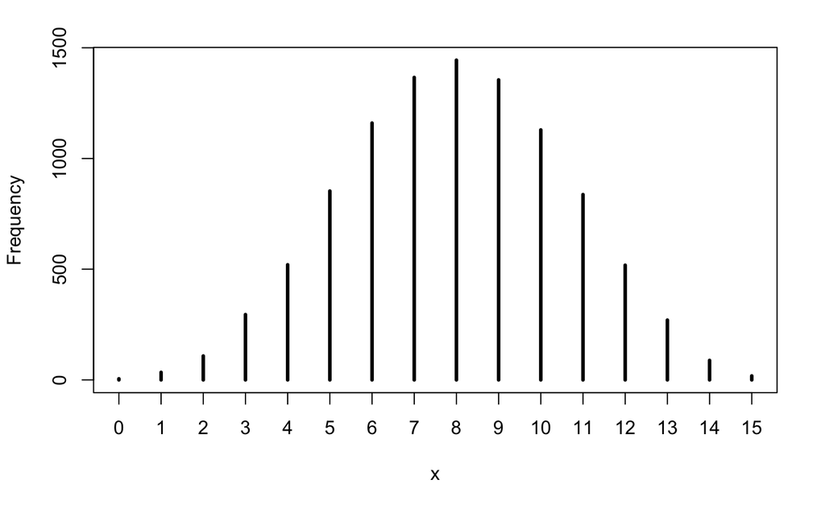

```r
w <- rbinom(1e4, size = 15, prob = samples)
simplehist(w)
```

```r
table(w) / length(w)
```

```
w
     0      1      2      3      4      5      6      7      8      9
0.0005 0.0034 0.0108 0.0295 0.0520 0.0853 0.1160 0.1366 0.1444 0.1355
    10     11     12     13     14     15
0.1129 0.0837 0.0518 0.0270 0.0088 0.0018
```

3m4

Probability of 6 water in 15 tosses is 11.7%

3m5

```r
# with step prior
p_grid <- seq(0, 1, length.out = 1e3)
prior <- ifelse(p_grid < 0.5, 0, 1)
likelihood <- dbinom(8, size = 15, prob = p_grid)
posterior <- (likelihood * prior) %>% {. / sum(.)}

# repeat earlier problems
HPDI(samples, prob = 0.9)
```

```
     |0.9      0.9|
0.3293293 0.7167167
```

```r
samples <- sample(p_grid, 1e4, prob = posterior, replace = TRUE)
w <- rbinom(1e4, size = 15, prob = samples)
table(w) / length(w)
```

```
w
     0      2      3      4      5      6      7      8      9     10
0.0001 0.0007 0.0040 0.0112 0.0338 0.0733 0.1128 0.1544 0.1770 0.1631
    11     12     13     14     15
0.1328 0.0831 0.0361 0.0142 0.0034
```

```r
# compare to p = 0.7 (true value)
dbinom(c(6, 8), 15, 0.7 )
```

```
[1] 0.01159000 0.08113003
```

### Hard

```r
data(homeworkch3)
# birth1 and birth2
```

3h1

```r
p_grid <- seq(0, 1, length.out = 1e3)
prior <- rep(1, length(p_grid))
likelihood <- dbinom(sum(c(birth1, birth2)),
                     size = length(c(birth1, birth2)),
                     prob = p_grid)
posterior <- (likelihood * prior) %>% {. / sum(.)}
p_grid[[which.max(posterior)]]
```

```
[1] 0.5545546
```

3h2

```r
samples <- sample(p_grid, 1e4, replace = TRUE, prob = posterior)
HPDI(samples, prob = c(0.5, 0.89, 0.97))
```

```
    |0.97     |0.89      |0.5      0.5|     0.89|     0.97|
0.4794795 0.5005005 0.5255255 0.5735736 0.6126126 0.6306306
```

3h3

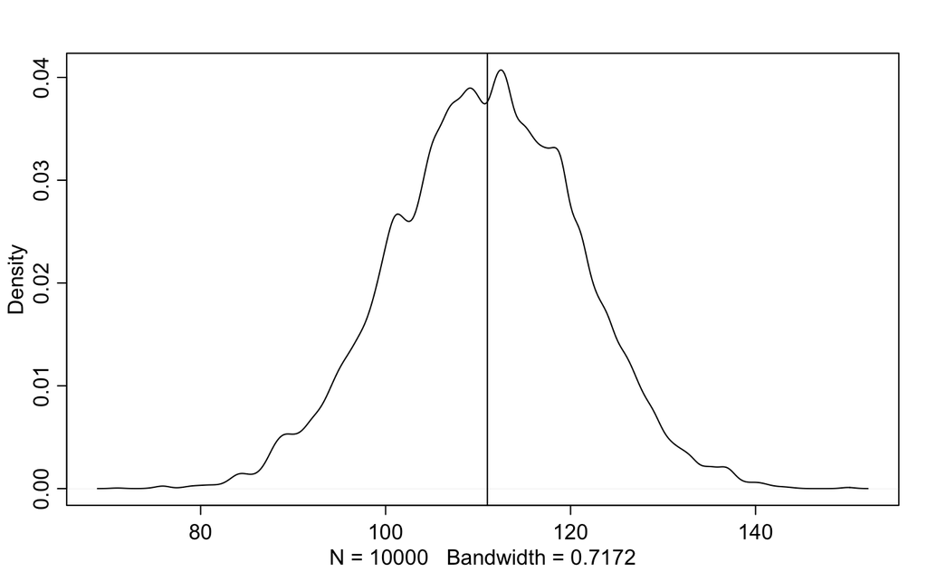

```r
simbirth <- rbinom(1e4, size = 200, prob = samples)
dens(simbirth)
abline(v = sum(birth1, birth2))
```

3h4

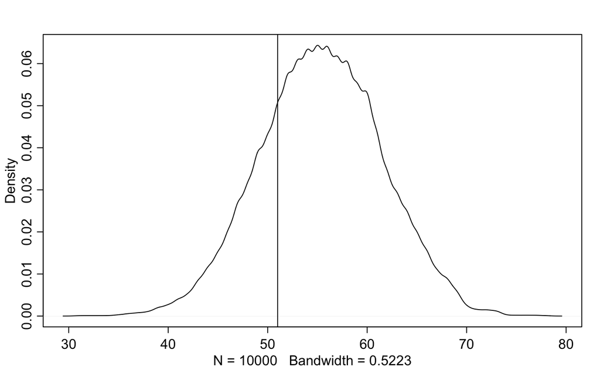

```r
simbirth <- rbinom(1e4, size = 100, prob = samples)
dens(simbirth, adj = 0.6)
abline(v = sum(birth1))
```

Model less accurate on first births

3h5

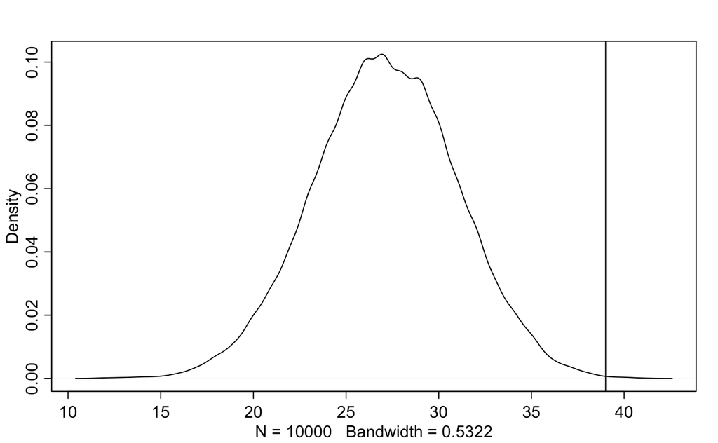

```r
simbirth <- rbinom(1e4, size = sum(!birth1), prob = samples)
dens(simbirth, adj = 1)
abline(v = sum(birth2[!birth1]))
```

The second child is more likely to be a boy following the birth of a girl.